# COVID 19 Data Report

J. Bakovich

2026-02-23

## Introduction

This document is an analysis of US and Global COVID-19 data presented by the Johns Hopkins GitHub website. The process conducted consists of importing, tidying, and analyzing/modeling the data, as well as providing some potential source of bias.

Through analysis, this document attempts to answer the following questions:

1. Which countries were the leaders in total case numbers and total death numbers?
2. How did the fatality rate of COVID-19 change over time? Did the date the vaccine was outsourced affect these results?
3. Globally, did the number of deaths match predictive analysis based on cases?

## Cleaning/Tidying the Data

To tidy and clean the data into the desired format, the following was completed:

- Pivoted the data to leverage the number of cases and deaths for each date, for each province/region
- Joined cases and deaths together into the same tables (‘US’ and ‘global’)

```r
global_cases <- global_cases %>%
  pivot_longer(cols = -c('Province/State', 'Country/Region', Lat, Long),
               names_to = "date",
               values_to = "cases") %>%
  select(-c(Lat,Long)) %>%
  mutate(date = mdy(date))

global_deaths <- global_deaths %>%
  pivot_longer(cols = -c('Province/State', 'Country/Region', Lat, Long),
               names_to = "date",
               values_to = "deaths") %>%
  select(-c(Lat,Long)) %>%
  mutate(date = mdy(date))

global <- global_cases %>%
  full_join(global_deaths) %>%
  rename(Country_Region = 'Country/Region', Province_State = 'Province/State')
```

```r
US_cases <- US_cases %>%
  pivot_longer(cols = -(UID:Combined_Key),
               names_to = "date",
               values_to = "cases") %>%
  select(Admin2:cases) %>%
  select(-c(Lat, Long_)) %>%
  mutate(date = mdy(date))

US_deaths <- US_deaths %>%
  pivot_longer(cols = -(UID:Combined_Key),
               names_to = "date",
               values_to = "deaths") %>%
  select(Admin2:deaths) %>%
  select(-c(Lat, Long_)) %>%
  mutate(date = mdy(date))

US <- US_cases %>% full_join(US_deaths)
```

## Visualizing the Data

### Part 1

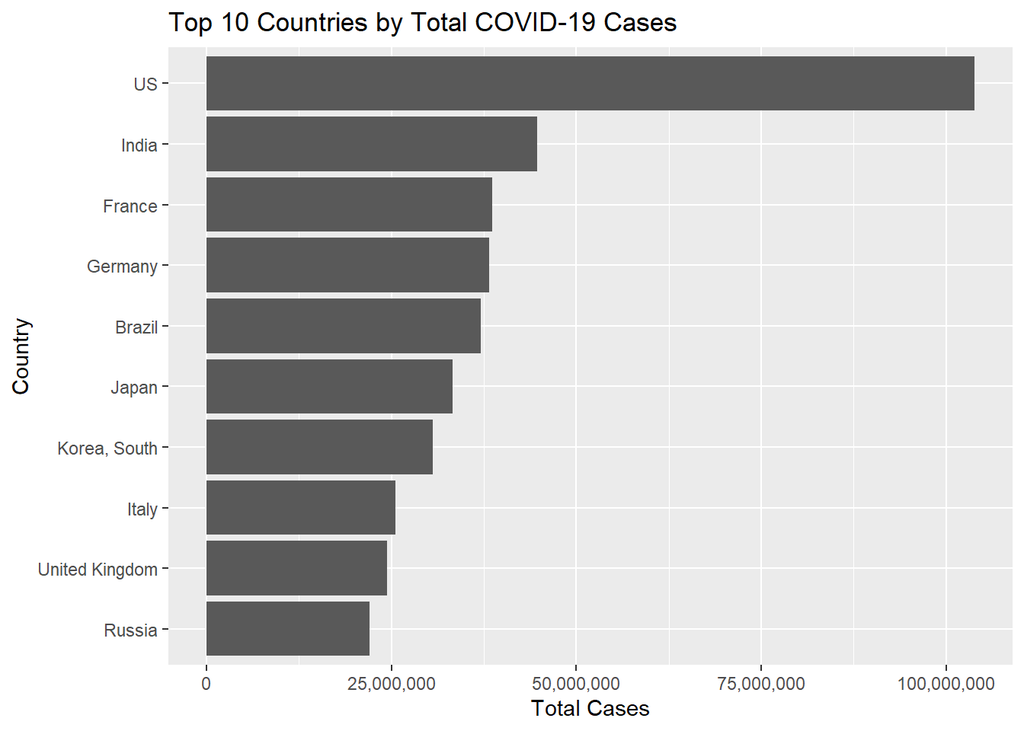

```r
top_cases <- global %>%
  group_by(Country_Region) %>%
  summarise(total_cases = max(cases, na.rm = TRUE)) %>%
  arrange(desc(total_cases)) %>%
  slice_head(n = 10)

ggplot(top_cases, aes(x = reorder(Country_Region, total_cases),
                       y = total_cases)) +
  geom_col() +
  coord_flip() +
  scale_y_continuous(labels = scales::comma) +
  labs(
    title = "Top 10 Countries by Total COVID-19 Cases",
    x = "Country",
    y = "Total Cases"
  )
```

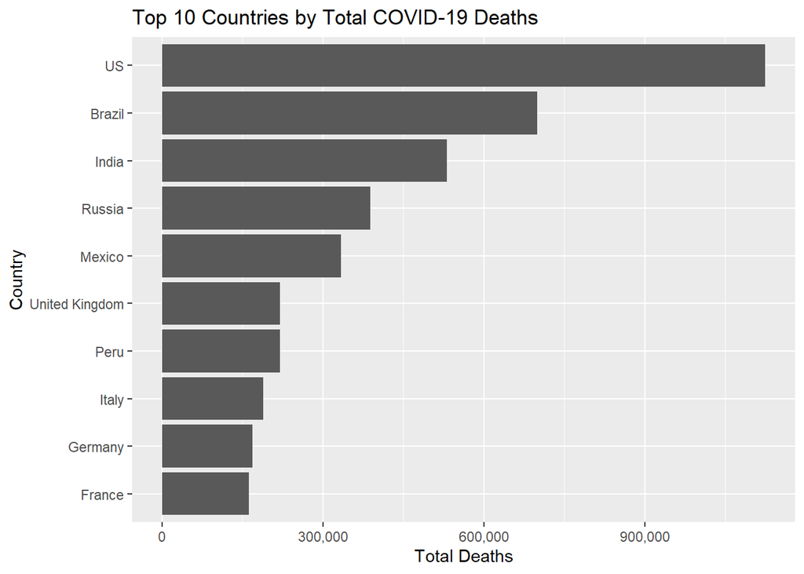

```r
top_deaths <- global %>%
  group_by(Country_Region) %>%
  summarise(total_deaths = max(deaths, na.rm = TRUE)) %>%
  arrange(desc(total_deaths)) %>%
  slice_head(n = 10)

ggplot(top_deaths, aes(x = reorder(Country_Region, total_deaths),
                        y = total_deaths)) +
  geom_col() +
  coord_flip() +
  scale_y_continuous(labels = scales::comma) +
  labs(
    title = "Top 10 Countries by Total COVID-19 Deaths",
    x = "Country",
    y = "Total Deaths"
  )
```

As shown by the figures, the US leads substantially in both the cases and death numbers. However, the rankings of cases and deaths vary by country following the American leaders. For example, India ranks #2 in cases but is #3 in deaths. An even stronger difference is Russia at #10 in cases, but rising to #4 in death totals.

### Part 2

The second question(s), “How did the fatality rate of COVID-19 change over time? Did the date the vaccine was outsourced affect these results?”, can be answered by plotting the fatality over time. The line graph below shows this plot, separating the global and US only trends. The vertical line represents the date that vaccines were first publicly administered.

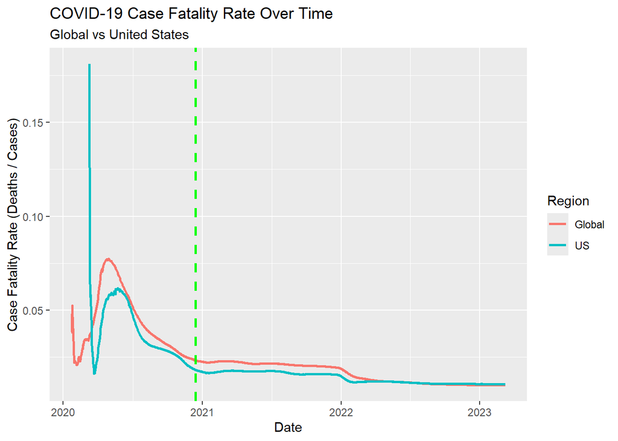

```r
global_daily <- global %>%
  filter(cases > 100) %>%
  group_by(date) %>%
  summarise(
    total_cases  = sum(cases, na.rm = TRUE),
    total_deaths = sum(deaths, na.rm = TRUE)
  ) %>%
  mutate(
    death_rate = total_deaths / total_cases
  )

US_daily <- US %>%
  filter(cases > 100) %>%
  group_by(date) %>%
  summarise(
    total_cases  = sum(cases, na.rm = TRUE),
    total_deaths = sum(deaths, na.rm = TRUE)
  ) %>%
  mutate(
    death_rate = total_deaths / total_cases
  )

death_rate_df <- bind_rows(
  global_daily %>% mutate(region = "Global"),
  US_daily %>% mutate(region = "US")
)

ggplot(death_rate_df, aes(x = date, y = death_rate, color = region)) +
  geom_line(size = 1) +
  labs(
    title = "COVID-19 Case Fatality Rate Over Time",
    subtitle = "Global vs United States",
    x = "Date",
    y = "Case Fatality Rate (Deaths / Cases)",
    color = "Region"
  ) +
  geom_vline(xintercept = as.Date("2020-12-14"),
             color = "green", linetype = "dashed", size = 1)
```

## Modeling the Data

To answer the third and final question, “Globally, did the number of deaths match predictive analysis based on cases?”, the graph below plot a linear regression model using lagged cases versus the number of deaths. This graph is meant to show how well the number of deaths matched case numbers from previous (with the weight of case to death ratio from that lagged point). From this, we can determine how well the deaths at a certain point matched the case totals (times fatality rate weight), from a week or so in the past.

```r
global_daily_lagged <- global_daily %>%
  mutate(
    cases_lag7  = lag(total_cases, 7),
    cases_lag14 = lag(total_cases, 14)
  ) %>%
  drop_na()

model <- lm(total_deaths ~ cases_lag7 + cases_lag14, data = global_daily_lagged)
summary(model)
```

```
##
## Call:
## lm(formula = total_deaths ~ cases_lag7 + cases_lag14, data = global_daily_lagged)
##
## Residuals:
##      Min       1Q   Median       3Q      Max
## -1091866  -500509  -306941   430058  1555553
##
## Coefficients:
##               Estimate Std. Error t value Pr(>|t|)
## (Intercept)  9.876e+05  3.764e+04   26.24   <2e-16 ***
## cases_lag7   1.151e-01  5.749e-03   20.01   <2e-16 ***
## cases_lag14 -1.061e-01  5.776e-03  -18.36   <2e-16 ***
## ---
## Signif. codes:  0 '***' 0.001 '**' 0.01 '*' 0.05 '.' 0.1 ' ' 1
##
## Residual standard error: 741600 on 1126 degrees of freedom
## Multiple R-squared:  0.9057, Adjusted R-squared:  0.9056
## F-statistic:  5409 on 2 and 1126 DF,  p-value: < 2.2e-16
```

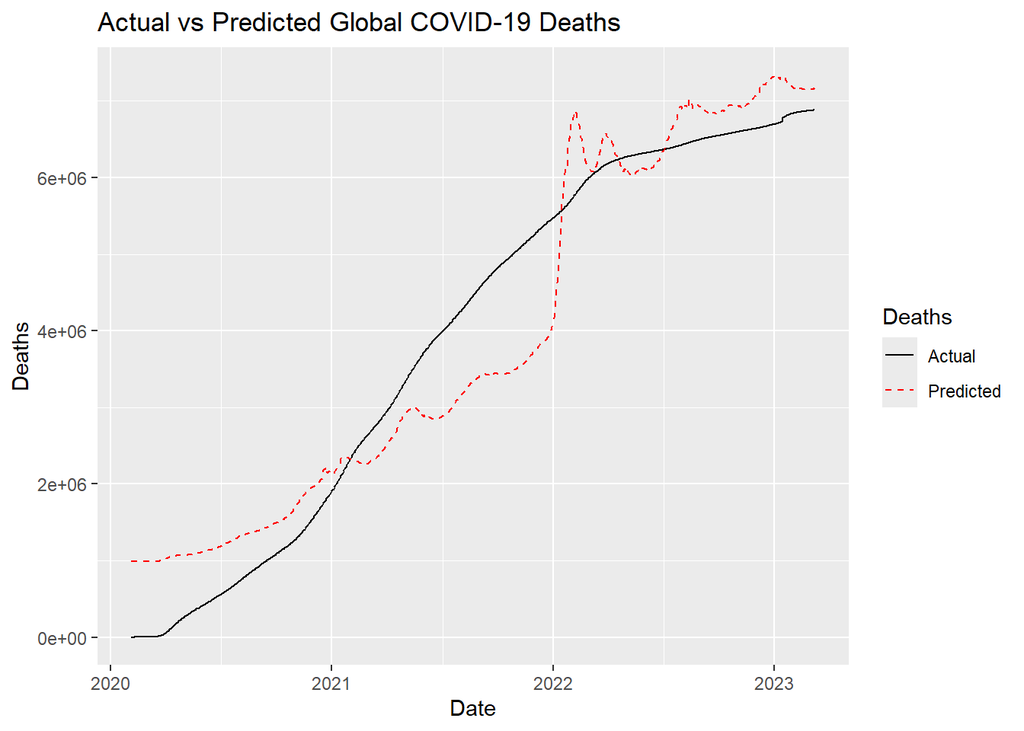

```r
global_daily_lagged <- global_daily_lagged %>%
  mutate(predicted_deaths = predict(model, newdata = global_daily_lagged))

ggplot(global_daily_lagged, aes(x = date)) +
  geom_line(aes(y = total_deaths, colour = "Actual")) +
  geom_line(aes(y = predicted_deaths, colour = "Predicted"), linetype = "dashed") +
    labs(
    title = "Actual vs Predicted Global COVID-19 Deaths",
    y = "Deaths",
    x = "Date"
  ) +
  scale_color_manual(name = "Deaths", values = c("Actual" = "black", "Predicted" = "red"))
```

## Conclusion and Sources of Bias

This report explored global and domestic COVID-19 trends through cleaning, visualization, and predictive modeling of Johns Hopkins GitHub data. By building the data from the ground up, meaningful insights were extracted regarding country-wide case and death totals, changes in fatality rate over time, and the relationships between cases and their subsequent deaths.

However, several sources of bias may affect these conclusions. One of these sources is the widespread under reporting of infections/death, especially in the early stages of the pandemic. These reporting failures are very likely to have skewed the data set in the early months, underestimated the number of cases and deaths. Another source of bias is difference in testing availability, especially in regards to global standards. While countries like the US, Russia, and India led the number of cases and deaths, this does not necessarily mean they lead, but rather they lead in reported cases and deaths. It is probable that other countries be contenders as leaders of cases and deaths (or cases and deaths per capita) if testing availablity was equivalent worldwide.